# Derivation of time-independent growth functions

R. Molowny-Horas

2024-10-03

## Introduction

Growth, understood as an increment along the physical dimensions of an organism, characterizes the temporal dynamics of many living entities better than many other features. By physical dimensions or size, terms that will be used indistinctly hereafter, we mean quantities that are directly related to the spatial space occupied by an organism (e.g. diameter and height for trees, length or weight for animals). Thus, those physical dimensions will increase at varying rate as the organism ages.

Size is often easier to determine experimentally than age. Only under controlled conditions in a laboratory or field experiment can we observe the birth or germination of animals or plants, and follow each single organism continuously and methodically to determine exactly their life span. However, in natural experiments like forest inventories, observers do not have control over experimental conditions and, therefore, the age of an individual is seldom precisely quantifiable.

Even under ideal conditions, growth of an organism is hampered by structural and physiologically constraints, which gradually set in as the organism gets larger. Those constraints usually make its growth rate (i.e. increment in size per unit time) to slow down beyond some point, approaching zero as time tends to infinite. We will hereby discard those cases in which growth rate in size may become zero or even negative (i.e. size reduction) due to, for example, worsening environmental conditions or fiercer competition. It may thus seem reasonable to assume that, for an organism, there is an upper limit for size which is only reached at an advanced age and under the most optimum climatic and environmental conditions. That upper limit is usually unknown but may be guessed by extrapolating observed trends. In addition, the upper-limit assumption suggests that sigmoid curves may be a good analytic model to describe size as a function of time, since sigmoid curves are monotonically increasing and are also constrained by lower and upper asymptote.

Let $y(t)$ be a continuous and differentiable sigmoid-like curve, which depends on time or age $t$. Given two time points $t_{1}$ and $t_{2}$, where $t_{1}<t_{2}$, then growth , defined as $y(t_{2})-y(t_{1})$, will simply be an unknown function $f\left(t_{1}, t_{2}\right)$. Expressed this way, that function $f\left(t_{1}, t_{2}\right)$ depends explicitly on absolute age/time at $t_{1}$ and $t_{2}$, which are usually unknown quantities in natural experiments. To determine growth independent of age/time, we will seek an analytic expression that is instead a function of the time interval $\Delta=t_{2}-t_{1}$, a relative quantity that is much easier to obtain. That is, we want to be find a new growth function $g$:

$$\begin{equation}
f\left(t_{1}, t_{2}\right)=g\left(\Delta\right)
\end{equation}$$

Those expressions should also incorporate a specific way to determine their dependence on a given set of explanatory variables like e.g. climate, landscape, competition, etc.

## Notation followed throughout the package

- $t$, $t_{1}$ and $t_{2}$: time points, where $t_{1}\leq t_{2}$.
- $\Delta$: time difference, $\Delta = t_{2} - t_{1}$
- $y_{1}$ and $y_{2}$: size at time points $t_{1}$ and $t_{2}$, respectively. It is assumed throughout that $y_{1}\leq y_{2}$.
- $k$: growth rate parameter. The dependence of growth on a set of explanatory variables is conveyed through this parameter.
- $\mathcal{X}$: set of explanatory variables on which growth will depend on through $k$.
- $a_{i}$: coefficients that multiply variables in the set $\mathcal{X}$.
- $A$: asymptotic maximum size.
- $B$: offset term.
- $g\left(\Delta\right)$: growth function such that $y_{2}=y_{1}+g\left(\Delta\right)$.

## Methodology

We will derive time-independent (also known as age-independent) curves for several $g\left(\Delta\right)$ functions. These curves have all been derived from sigmoid age-dependent size curves, which implies that there is always an asymptotic maximum size $A$. Some curves are well-known and widely used (e.g. logistic, Schumacher, Gompertz, monomolecular) whereas others are more rarely employed (e.g. arctangent, hyperbolic tangent).

To convey the dependence of growth on a given set of explanatory variables $\mathcal{X}$ like e.g. climate, landscape, competition, we will use the aforementioned parameter $k$ as a linear function:

$$\begin{equation}
k=\sum_{i=1}^{n} a_{i}\cdot \mathcal{X}_{i}
\end{equation}$$

which, in turn, multiplies age/time $t$. Many age-dependent size curves, and their corresponding age-independent expressions, are highly non-linear in $k$. Thus, a successful fitting strategy requires the implementation of a non-linear regression algorithm to calculate the coefficients $a_{i}$ that determine the effect of the corresponding explanatory variable. As we will see below, this strategy yields relatively simple expressions that can readily be implemented as time-independent growth functions.

In addition, term $B$ represents an (a priori unknown) offset in the growth curve. Nevertheless, as we will see below, this summative offset $B$ conveniently vanishes in all cases when $g\left(\Delta\right)$ or $k$ are expressed as a function of $\Delta$. Finally, in all expressions it is easy to check that $g\left(\Delta\right)=0$ when $\Delta=0$ or $k=0$ always, as expected.

#### 1. Logistic

The logistic curve, labelled *Autocatalytic* in Richards’ original article, is one of the most widely used sigmoid functions to determine the growth of an individual plant or animal. In a general case, in which size depends on time $t$ as well as on a set of predictors (e.g. climatic, topographic), the size $y$ of an organism that obeys the logistic rule can be written:

$$\begin{equation}
y=\frac{A}{1+e^{-\left(k\cdot t+B\right)}}
\end{equation}$$

As mentioned above, the dependence on predictors is done through $k$. To obtain a time-independent equation that determines growth between two time points $t_{1}$ and $t_{2}$, $t_{1}<t_{2}$, we start by writing:

$$\begin{equation}
e^{-\left(k\cdot t+B\right)}=\frac{A}{y}-1
\end{equation}$$

and:

$$\begin{equation}
t=\frac{1}{k}\cdot \ln\left(\frac{y}{A-y}\right)-B
\end{equation}$$

Let us define a subscript notation whereby $t_{1}$ and $t_{2}$ indicate time points separated by $\Delta$ years, where $\Delta=t_{2}-t_{1}$. Likewise, $y_{1}$ and $y_{2}$ will denote sizes at those time points, respectively. Then:

$$\begin{equation}
\Delta
=t_{2}-t_{1}=\frac{1}{k}\cdot\left[\ln\left(\frac{y_{2}}{y_{1}}\cdot\frac{A-y_{1}}{A-y_{2}}\right)\right]
\end{equation}$$

The $B$ coefficient has conveniently disappeared from the equation. Now we can easily deduce the following expression for $k$:

$$\begin{equation}
k=\frac{1}{\Delta}\cdot\left[\ln\left(\frac{y_{2}}{y_{1}}\cdot\frac{A-y_{1}}{A-y_{2}}\right)\right]
\end{equation}$$

Since $t_{2}=t_{1}+\Delta$, we can arrive at an expression for $y_{2}$ as a function of $y_{1}$, $\Delta$ and the coefficients $a_{i}$:

$$\begin{equation}
y_{2}=\frac{A}{1+e^{-\left(k\cdot t_{1}+B\right)}\cdot
e^{-k\cdot\Delta}}=\frac{A}{1+\left(\frac{A}{y_{1}}-1\right)\cdot
e^{-k\cdot\Delta}}
\end{equation}$$

Finally, growth can be expressed as:

$$\begin{equation}
g\left(\Delta\right)=\frac{A}{1+e^{-\left(k\cdot t_{1}+B\right)}\cdot
e^{-k\cdot\Delta}}-y_{1}=\frac{A}{1+\left(\frac{A}{y_{1}}-1\right)\cdot
e^{-k\cdot\Delta}}-y_{1}
\end{equation}$$

#### 2. Schumacher

The Schumacher growth curve can be expressed as:

$$\begin{equation}
y=A\cdot e^{-\frac{1}{k\cdot t+B}}
\end{equation}$$

For this curve to make ecological sense, $k\cdot t+B\geq 0$ always. Otherwise, $y$ would grow exponentially when $k\cdot t+B< 0$. Then, we can express $t$ as:

$$\begin{equation}
t=\frac{1}{k}\cdot\frac{1}{\ln\left(\frac{A}{y}\right)}-\frac{1}{k}\cdot
B
\end{equation}$$

Now, following the same procedure as above, we write:

$$\begin{equation}
\Delta=\frac{1}{k}\cdot\left[\frac{1}{\ln\left(\frac{A}{y_{2}}\right)}-\frac{1}{\ln\left(\frac{A}{y_{1}}\right)}\right]
\end{equation}$$

As above, the offset $B$ has vanished from the equation. Then:

$$\begin{equation}
k=\frac{1}{\Delta}\cdot\left[\frac{1}{\ln\left(\frac{A}{y_{2}}\right)}-\frac{1}{\ln\left(\frac{A}{y_{1}}\right)}\right]
\end{equation}$$

Solving the equation for $y_{2}$:

$$\begin{equation}
y_{2}=A\cdot
e^{-\left[\frac{1}{\frac{1}{\ln\left(\frac{A}{y_{1}}\right)}+k\cdot\Delta}\right]}
\end{equation}$$

This is exactly Equation [9] in Tomé et al. (2006). Then, the Schumacher time-independent growth function becomes:

$$\begin{equation}
g\left(\Delta\right)=A\cdot
e^{-\left[\frac{1}{\frac{1}{\ln\left(\frac{A}{y_{1}}\right)}+k\cdot\Delta}\right]}-y_{1}
\end{equation}$$

#### 3. Gompertz

The Gompertz function has long been used by the actuarial sciences to build life-tables. It is expressed as:

$$\begin{equation}
y=A\cdot e^{-e^{-\left(k\cdot t+B\right)}}
\end {equation}$$

where B is an offset. Again, we can manipulate that equation to extract $t$:

$$\begin{equation}
t=\frac{1}{k}\cdot\left[\ln\left(\frac{1}{\ln\left(\frac{A}{y}\right)}\right)-B\right]
\end{equation}$$

Defining, as before, $\Delta=t_{2}-t_{1}$ we obtain:

$$\begin{equation}
\Delta=\frac{1}{k}\cdot\ln\left(\frac{\ln\left(\frac{A}{y_{1}}\right)}{\ln\left(\frac{A}{y_{2}}\right)}\right)
\end{equation}$$

Thus:

$$\begin{equation}
k=\frac{1}{\Delta}\cdot\ln\left(\frac{\ln\left(\frac{A}{y_{1}}\right)}{\ln\left(\frac{A}{y_{2}}\right)}\right)
\end{equation}$$

Finally, we arrive at:

$$\begin{equation}
y_{2}=A\cdot\left(\frac{y_{1}}{A}\right)^{e^{-k\cdot\Delta}}
\end{equation}$$

and:

$$\begin{equation}
g\left(\Delta\right)=A\cdot\left(\frac{y_{1}}{A}\right)^{e^{-k\cdot\Delta}}-y_{1}
\end{equation}$$

#### 4. Monomolecular

The monomolecular growth function does not have a smooth initial growth, as other curves discussed in this document. It grows very fast at $t=0$ and gradually slows down until towards an asymptotic value. Its functional expression is as follows:

$$\begin{equation}
y=A\cdot \left(1-e^{-\left( k\cdot t+B\right)}\right)
\end {equation}$$

If we extract $t$ we get:

$$\begin{equation}
t=\frac{1}{k}\cdot \left[\ln\left(\frac{A}{A-y}\right)-B\right]
\end {equation}$$

and then:

$$\begin{equation}
\Delta=\frac{1}{k}\cdot
\left[\ln\left(\frac{A-y_{1}}{A-y_{2}}\right)\right]
\end {equation}$$

The growth rate parameter is:

$$\begin{equation}
k=\frac{1}{\Delta}\cdot
\left[\ln\left(\frac{A-y_{1}}{A-y_{2}}\right)\right]
\end {equation}$$

Then, size at $t_{2}$ is:

$$\begin{equation}
y_{2}=A-\left(A-y_{1}\right)\cdot e^{-k\cdot \Delta}
\end {equation}$$

and, finally, age/time-independent growth can be written as:

$$\begin{equation}
g\left(\Delta\right)=\left(A-y_{1}\right)\cdot\left(1-e^{-k\cdot
\Delta}\right)
\end {equation}$$

#### 5. Squared monomolecular

With a simple modification it is possible to give a smooth initial growth to the monomolecular growth function. By squaring the term inside the parenthesis we get:

$$\begin{equation}
y=A\cdot \left(1-e^{-\left( k\cdot t+B\right)^{2}}\right)
\end {equation}$$

Term $k$ is straightforward to obtain after some easy algebra:

$$\begin{equation}
k=\frac{1}{t}\cdot\sqrt{-\ln\left(1-\frac{y}{A}\right)}
\end {equation}$$

Then:

$$\begin{equation}
k\cdot\Delta=\sqrt{-\ln\left(1-\frac{y_{2}}{A}\right)}-\sqrt{-\ln\left(1-\frac{y_{1}}{A}\right)}
\end {equation}$$

Finally, we show the explicit form of $y_{2}$ as:

$$\begin{equation}
y_{2}=A\cdot\left(1-e^{-\left(k\cdot\Delta+\sqrt{-\ln\left(1-\frac{y_{1}}{A}\right)}\right)}\right)
\end {equation}$$

Therefore, the growth function will be:

$$\begin{equation}
g\left(\Delta\right)=A\cdot\left(1-e^{-\left(k\cdot\Delta+\sqrt{-\ln\left(1-\frac{y_{1}}{A}\right)}\right)}\right)-y{1}
\end {equation}$$

#### 6. Arctangent

The arctangent is another sigmoid curve from which a time-independent growth function can be derived relatively easily. We start by expressing growth as a function of time:

$$\begin{equation}
y=A\cdot \left(\frac{1}{\pi}\cdot \arctan\left(k\cdot
t+B\right)+0.5\right)
\end {equation}$$

Thus, growth $y\in \left[0,A\right]$ and $B$ has been included to allow for any possible offset in the curve, as before. We can easily get:

$$\begin{equation}
k\cdot t=\tan\left[\left(\frac{y}{A}-0.5\right)\cdot\pi\right]-B
\end{equation}$$

Therefore:

$$\begin{equation}
t=\frac{1}{k}\cdot\tan\left[\left(\frac{y}{A}-0.5\right)\cdot\pi\right]-B
\end{equation}$$

and, thus:

$$\begin{equation}
\Delta=\frac{1}{k}\cdot\left[\tan\left(\left(\frac{y_{2}}{A}-0.5\right)\cdot\pi\right)-\tan\left(\left(\frac{y_{1}}{A}-0.5\right)\cdot\pi\right)\right]
\end{equation}$$

Thus, the offset term $B$ has vanished from the equation. An equivalent expression for $k$ is:

$$\begin{equation}
k=\frac{1}{\Delta}\cdot\left[\tan\left(\left(\frac{y_{2}}{A}-0.5\right)\cdot\pi\right)-\tan\left(\left(\frac{y_{1}}{A}-0.5\right)\cdot\pi\right)\right]
\end{equation}$$

Finally, we derive:

$$\begin{equation}
\tan\left(\left(\frac{y_{2}}{A}-0.5\right)\cdot\pi\right)=\tan\left(\left(\frac{y_{1}}{A}-0.5\right)\cdot\pi\right)+k\cdot\Delta
\end{equation}$$

and then:

$$\begin{equation}
y_{2}=A\cdot\left[\frac{1}{\pi}\cdot
\arctan\left\{\tan\left(\left(\frac{y_{1}}{A}-0.5\right)\cdot\pi\right)+k\Delta\right\}+0.5\right]
\end{equation}$$

The growth function is, then:

$$\begin{equation}
g\left(\Delta\right)=A\cdot\left[\frac{1}{\pi}\cdot
\arctan\left\{\tan\left(\left(\frac{y_{1}}{A}-0.5\right)\cdot\pi\right)+k\Delta\right\}+0.5\right]-y_{1}
\end{equation}$$

#### 7. Hyperbolic tangent

The hyperbolic tangent growth function is seldom used in growth studies. We start by expressing size $y$ as a function of $t$ as follows:

$$\begin{equation}
y\left(t\right)=A\cdot\left[\tanh\left(k\cdot t+B\right)+1\right]=
\frac{A}{2}\left[\cdot\frac{e^{2\cdot\left(k\cdot
t+B\right)}-1}{e^{2\cdot\left(k\cdot t+B\right)}+1}+1\right]
\end{equation}$$

We can then write:

$$\begin{equation}
y=A\cdot\frac{e^{2\cdot\left(k\cdot t+B\right)}}{e^{2\cdot\left(k\cdot
t+B\right)}+1}=A\cdot\frac{1}{1+e^{-2\cdot\left(k\cdot t+B\right)}}
\end {equation}$$

This is exactly the same as the logistic function above if we substitute $2\cdot k=k'$. Therefore, it is straightforward to arrive at the following expressions:

$$\begin{equation}
\Delta=\frac{1}{2\cdot
k}\cdot\left[\ln\left(\frac{y_{2}}{y_{1}}\cdot\frac{A-y_{1}}{A-y_{2}}\right)\right]
\end{equation}$$

and:

$$\begin{equation}
k=\frac{1}{2\cdot\Delta}\cdot\left[\ln\left(\frac{y_{2}}{y_{1}}\cdot\frac{A-y_{1}}{A-y_{2}}\right)\right]
\end{equation}$$

Finally, we obtain:

$$\begin{equation}
y_{2}=\frac{A}{1+\left(\frac{A}{y_{1}}-1\right)\cdot e^{-2\cdot
k\cdot\Delta}}
\end{equation}$$

Growth can thus be expressed as:

$$\begin{equation}
g\left(\Delta\right)=\frac{A}{1+\left(\frac{A}{y_{1}}-1\right)\cdot
e^{-2\cdot k\cdot\Delta}}-y_{1}
\end{equation}$$

Thus, the hyperbolic tangent growth function is simply a rescaled version of the logistic growth function, o vice versa.

#### 8. Arctangent exponential

Similar to the arctangent growth function above, the arctangent exponential follows a sigmoid shape, although the slope of its middle part is steeper and it reaches the lower or upper plateau quicker. It can be expressed as follows:

$$\begin{equation}
y=A\cdot \left(\frac{2}{\pi}\cdot \arctan\left(e^{k\cdot
t+B}\right)\right)
\end {equation}$$

With some algebra we can obtain an explicit expression for the $k$:

$$\begin{equation}
k=\frac{1}{t}\left(\ln\left(\tan\left(\frac{\pi}{2\cdot A}\cdot
y\right)\right)-B\right)
\end {equation}$$

It is also easy to get an expression for $k\cdot\Delta$, in which the term $B$ is now gone:

$$\begin{equation}
k\Delta=\ln\left(\frac{\tan\left(\frac{\pi}{2\cdot A}\cdot
y_{2}\right)}{\tan\left(\frac{\pi}{2\cdot A}\cdot y_{1}\right)}\right)
\end {equation}$$

Undoing this equation to express $y_{2}$ as a function of all other terms we come to:

$$\begin{equation}
y_{2}=\frac{\pi}{2\cdot A}\cdot
\arctan\left(\tan\left(\frac{\pi}{2\cdot A}\right)\cdot
e^{k\cdot\Delta}\right)
\end {equation}$$

Finally, size growth is simply:

$$\begin{equation}
g\left(\Delta\right)=\frac{\pi}{2\cdot A}\cdot
\arctan\left(\tan\left(\frac{\pi}{2\cdot A}\right)\cdot
e^{k\cdot\Delta}\right)-y{1}
\end {equation}$$

#### 9. Rational

Rational functions can also behave in a sigmoid-like fashion. In particular, the following function:

$$\begin{equation}
y=\frac{A}{2}\cdot\left(\frac{k\cdot t+B}{\sqrt{1+\left(k\cdot
t+B\right)^{2}}}+1\right)
\end {equation}$$

It is straightforward to derive an explicit expression for $k$:

$$\begin{equation}
k=\frac{1}{t}\cdot \frac{1}{\sqrt{\frac{1}{2\cdot\frac{y}{A}-1}}}-B
\end {equation}$$

As before, evaluating this equation in $t_{1}$ and $t_{2}$ enables us to show that:

$$\begin{equation}
k\cdot\Delta = \frac{y_{2}}{\sqrt{1-y_{2}^{2}}} -
\frac{y_{1}}{\sqrt{1-y_{1}^{2}}}
\end {equation}$$

Reordering and squaring we get:

$$\begin{equation}
\frac{y_{2}^{2}}{1-y_{2}^{2}}=\frac{1}{\frac{1}{y_{2}^{2}}-1}=\left(k\cdot\Delta
+ \frac{y_{1}}{\sqrt{1-y_{1}^{2}}}\right)^{2}
\end {equation}$$

Finally, some further algebraic manipulation allows to write:

$$\begin{equation}
y_{2}=\sqrt{\frac{1}{1+\frac{1}{\left(k\cdot\Delta +
\frac{y_{1}}{\sqrt{1-y_{1}^{2}}}\right)^{2}}}}
\end {equation}$$

Thus, growth in the case of this rational function will be given by:

$$\begin{equation}
g\left(\Delta\right)=\frac{A}{\sqrt{1+\frac{1}{\left(k\cdot\Delta +
\frac{y_{1}}{\sqrt{1-y_{1}^{2}}}\right)^{2}}}}-y_{1}
\end {equation}$$

### Comparison of curves.

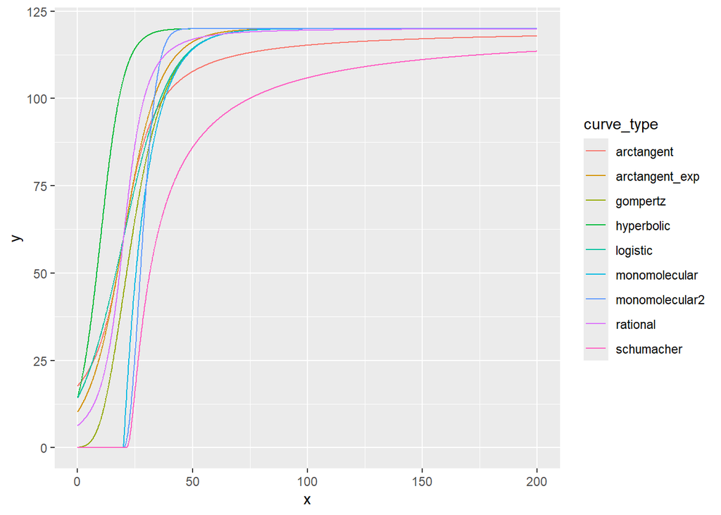

```r
t <- seq(0, 200, by = .1) ; k  <- 0.1 ; B <- -2
dat <- data.frame(t = t, k = 0.1, offset = -2, max_y = 120)
df <- data.frame(x = t, y = Rtigre::td_size(dat, curve_type = "logistic"), curve_type = "logistic")
for (i in Rtigre:::all_curve_types()[-c(1, 10)]) {
  y <- Rtigre::td_size(dat, curve_type = i)
  if (any(i %in% c("schumacher", "monomolecular", "monomolecular2"))) y[(k*t+B) < 0] <- 0
  df <- rbind(df, data.frame(x = t, y = y, curve_type = i))
}
print(ggplot2::ggplot(df, ggplot2::aes(x = x, y = y, colour = curve_type)) + ggplot2::geom_line())
```

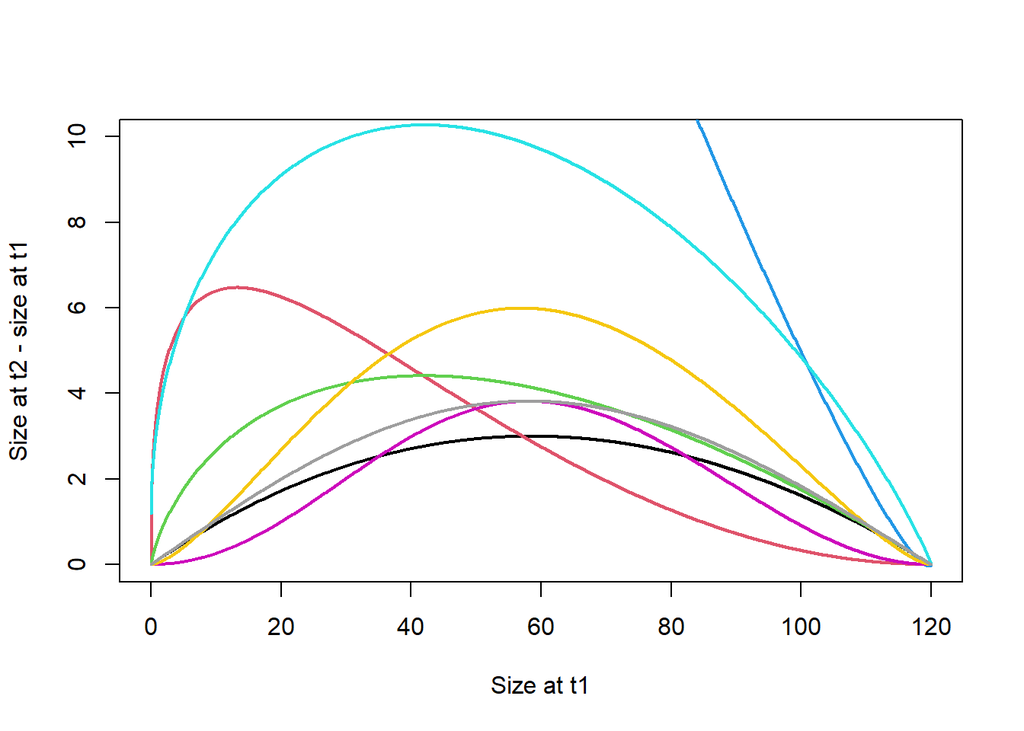

```r
tdiff <- 1
max_y <- 120
y1 <- seq(0, max_y, length = 1000)
k <- .1
dat <- data.frame(tdiff = tdiff, max_y = max_y, k = k, y1  = y1)
plot(y1, Rtigre::ti_size(dat)-dat$y1, xlab = "Size at t1",
     ylab = "Size at t2 - size at t1", type = "l", lwd = 2, col = 1, ylim = c(0, 10))
points(y1,Rtigre::ti_size(dat, "schumacher")-dat$y1, type = "l", lwd = 2, col = 2)
points(y1,Rtigre::ti_size(dat, "gompertz")-dat$y1, type = "l", lwd = 2, col = 3)
points(y1,Rtigre::ti_size(dat, "monomolecular")-dat$y1, type = "l", lwd = 2, col = 4)
points(y1,Rtigre::ti_size(dat, "monomolecular2")-dat$y1, type = "l", lwd = 2, col = 5)
points(y1,Rtigre::ti_size(dat, "arctangent")-dat$y1, type = "l", lwd = 2, col = 6)
points(y1,Rtigre::ti_size(dat, "rational")-dat$y1, type = "l", lwd = 2, col = 7)
points(y1,Rtigre::ti_size(dat, "arctangent_exp")-dat$y1, type = "l", lwd = 2, col = 8)
```